# Endothelial analysis

# General Setup

Setup chunk

Setup reticulate

```r
knitr::opts_chunk$set(fig.width = 8)
knitr::opts_knit$set(root.dir = normalizePath(".."))
knitr::opts_knit$get("root.dir")
```

```
[1] "/nas/groups/treutlein/USERS/tomasgomes/projects/liver_regen"
```

Load libraries

```r
library(reticulate)
knitr::knit_engines$set(python = reticulate::eng_python)
py_available(initialize = FALSE)
```

```
[1] TRUE
```

```r
use_python(Sys.which("python"))
py_config()
```

```
python:         /usr/bin/python
libpython:      /usr/lib64/python2.7/config/libpython2.7.so
pythonhome:     //usr://usr
version:        2.7.5 (default, May 30 2023, 03:38:55)  [GCC 4.8.5 20150623 (Red Hat 4.8.5-44)]
numpy:           [NOT FOUND]

NOTE: Python version was forced by use_python function
```

Functions

```r
getDPT = function(x){
  return(destiny:::dpt_for_branch(destiny::branch_divide(x, integer(0L)),
                                  min(destiny::branch_divide(x, integer(0L))@branch[, 1],
                                      na.rm = TRUE)))
}
CVgam = function (formula, data, nfold = 10, debug.level = 0, method = "glm.fit",
    printit = TRUE, cvparts = NULL, seed = 29){
  # modified from the `gamclass` package to use gam::gam
    if (is.null(cvparts)) {
        set.seed(seed)
        cvparts <- sample(1:nfold, nrow(data), replace = TRUE)
    }
    folds <- unique(cvparts)
    khat <- hat <- numeric(nrow(data))
    scale.gam <- summary(gam::gam(formula, data = data, method = method,
                                  family = mgcv::betar(link = "logit", eps = 0.00001)))$scale
    for (i in folds) {
        trainrows <- cvparts != i
        testrows <- cvparts == i
        elev.gam <- gam::gam(formula, data = data[trainrows, ],
                             method = method,
                             family = mgcv::betar(link = "logit", eps = 0.00001))
        hat[testrows] <- predict(elev.gam, newdata = data[testrows,], select = T, type = "response")
        res <- residuals(elev.gam)
    }
    y <- eval(formula[[2]], envir = as.data.frame(data))
    res <- y - hat
    cvscale <- sum(res^2)/length(res)
    prntvec <- c(GAMscale = scale.gam, `CV-mse-GAM ` = cvscale)
    if (printit)
        print(round(prntvec, 4))
    invisible(list(fitted = hat, resid = res, cvscale = cvscale,
        scale.gam = scale.gam))
}
fittingFunc = function(g){
  t = sub_dat$zonation_pt
  gene_fit_p = c()
  gene_fit_vals = data.frame(row.names = 1:100)
  z = sub_dat@assays$SCT@data[g,]

  d = data.frame(z=z, t=t)
  tmp = suppressMessages(gam(z ~ ns(t, df = 3), data=d))

  # bins for model fitting
  bb = seq(min(t), max(t), length.out = 100)
  gene_fit_vals[,g] = suppressMessages(predict(tmp,
                                               newdata = data.frame(t = bb)))
  p = summary(tmp)$parametric.anova$`Pr(>F)`[1]
  gene_fit_p = c(gene_fit_p, p)
  names(gene_fit_p)[length(gene_fit_p)] = g

  return(list("fits" = gene_fit_vals, "pval" = gene_fit_p))
}
minmax_scale = function(x){
  return((x-min(x))/(max(x)-min(x)))
}
getTopTerms = function(godf, topt = 100, ncl = 5, nt = 2){
  topt = if(nrow(godf)<topt) nrow(godf) else topt
  if(nrow(godf)<ncl) return(godf)
  df = godf[1:topt,]
  genes = sapply(df$geneID, function(x) strsplit(x, "/"))
  resmat = matrix(0, length(genes), length(genes))
  for(i in 1:length(genes)){
    for(j in 1:length(genes)){
      resmat[i,j] = length(intersect(genes[[i]], genes[[j]]))/length(genes[[i]])
    }
  }
  cl = hclust(dist(resmat), method = "ward.D2")
  cl = cutree(cl, ncl)
  res_df = data.frame("Description" = df$Description, "qvalue" = df$qvalue, "geneID" = df$geneID,
                      cl, stringsAsFactors = F)
  res_df = res_df[order(res_df$qvalue, decreasing = F),]
  topterms = unlist(tapply(res_df$Description, res_df$cl, function(x) x[1:nt]))
  res_df = res_df[res_df$Description %in% topterms,]

  return(res_df)
}
```

Load data (from all cells)

```r
allcells_css = readRDS(file = "data/processed/allcells_css.RDS")
```

# Healthy endothelial analysis for UMAP and signature plots

Subset and process each condition (only LSEC)

```r
end_cells = list()
for(cond in unique(allcells_css@meta.data$Condition)){
  cat(cond)
  end_cells[[cond]] = allcells_css[,grepl("LSEC ", allcells_css@meta.data$allcells_clusters) &
                                     allcells_css@meta.data$Condition==cond]
  if(cond=="healthy"){
    end_cells[[cond]] = end_cells[[cond]][,grepl("LSEC ", end_cells[[cond]]@meta.data$names_clusters)]
  }
  print(dim(end_cells[[cond]]))
  end_cells[[cond]] = suppressWarnings(SCTransform(end_cells[[cond]], do.correct.umi = T,
                                                   verbose = F,
                                                   vars.to.regress=c("unique_name","nCount_RNA"),
                                                   variable.features.rv.th = 1, seed.use = 1,
                                                   return.only.var.genes = F,
                                                   variable.features.n = NULL))
  end_cells[[cond]] = RunPCA(end_cells[[cond]], verbose = F)
  end_cells[[cond]] = RunUMAP(end_cells[[cond]], dims = 1:20, verbose = F)
}
```

For healthy cells (which will serve as reference), do additional filtering and reprocessing

```r
DimPlot(end_cells$healthy, reduction = "umap", group.by = "allcells_clusters")
gfresh = c("CLEC1B", "CLEC4G", "LYVE1", "CD14",  # central
           "PECAM1", "AQP1", "VWF", "CD34", # portal
           "ALB", "MKI67", "TRAC", "DCN")
FeaturePlot(end_cells$healthy, features = gfresh, reduction = "umap")

outcells = (end_cells$healthy@reductions$umap@cell.embeddings[,1]<(-4)) # this removes what seem to be central hepatocytes
end_cells$healthy = end_cells$healthy[,!outcells]

end_cells$healthy = suppressWarnings(SCTransform(end_cells$healthy, do.correct.umi = T,
                                                 verbose = F,
                                                 vars.to.regress = c("unique_name","nCount_RNA"),
                                                 variable.features.rv.th = 1, seed.use = 1,
                                                 return.only.var.genes = F,
                                                 variable.features.n = NULL))
end_cells$healthy = RunPCA(end_cells$healthy, verbose = F)
end_cells$healthy = RunUMAP(end_cells$healthy, dims = 1:15, verbose = F)
DimPlot(end_cells$healthy, reduction = "umap", group.by = "unique_name")

end_cells$healthy = FindNeighbors(end_cells$healthy, reduction = "pca", dims = 1:15,
                                  force.recalc = T, graph.name = "end")
end_cells$healthy = FindClusters(end_cells$healthy, graph.name = "end", algorithm = 2,
                                 resolution = seq(0.1,0.8,0.1), verbose = F)
DimPlot(end_cells$healthy, reduction = "umap", group.by = "end_res.0.2")
end_cells$healthy = SetIdent(end_cells$healthy, value = "end_res.0.2")
mk_end_h = FindAllMarkers(end_cells$healthy, assay = "SCT")

saveRDS(end_cells$healthy, file = "results/zonation_healthy/end_healthy_srat.RDS")
```

# Endothelial cell clustering

Subset LSEC

```r
all_end_cells = allcells_css[,grepl("LSEC", allcells_css@meta.data$allcells_clusters)]
all_end_cells = suppressWarnings(SCTransform(all_end_cells, do.correct.umi = T, verbose = F,
                                             vars.to.regress=c("unique_name","nCount_RNA"),
                                             variable.features.rv.th = 1, seed.use = 1,
                                             return.only.var.genes = F,
                                             variable.features.n = NULL))
all_end_cells = RunPCA(all_end_cells, verbose = F)
all_end_cells = RunUMAP(all_end_cells, dims = 1:25, verbose = F)
DimPlot(all_end_cells, reduction = "umap", group.by = "Condition")
DimPlot(all_end_cells, reduction = "umap", group.by = "allcells_simp")
DimPlot(all_end_cells, reduction = "umap", group.by = "Donor")
DimPlot(all_end_cells, reduction = "umap", group.by = "Phase")
FeaturePlot(all_end_cells, reduction = "umap", features = c("MKI67", "ALB", "S100A8", "COLEC11",
                                                            "CLEC1B", "CLEC14A", "AQP1", "MGP",
                                                            "LYVE1", "PROX1", "CD14", "PECAM1",
                                                            "VWF", "INMT", "PLVAP", "RBP7"))
```

Cluster and get markers

```r
all_end_cells = FindNeighbors(all_end_cells, reduction = "pca", dims = 1:25,
                              prune.SNN = 1/5, force.recalc = T, graph.name = "pca25")
all_end_cells = FindClusters(all_end_cells, algorithm = 2, verbose = F, graph.name = "pca25",
                             resolution = seq(0.1, 2, 0.1))
DimPlot(all_end_cells, reduction = "umap", group.by = "pca25_res.1", label = T)
DimPlot(all_end_cells, reduction = "umap", group.by = "Donor", label = F)
DimPlot(all_end_cells, reduction = "umap", group.by = "Condition", label = F)

all_end_cells = SetIdent(all_end_cells, value = "pca25_res.1")
mkend = FindAllMarkers(all_end_cells, logfc.threshold = 0.2, pseudocount.use = 0.1)
write.csv(mkend[mkend$p_val_adj<=0.05,],
          file = "results/endothelial/markers_endo_subpop_all.csv", row.names = T, quote = F)

saveRDS(mkend, file = "./results/endothelial/clust_markers_endo.RDS")
```

Annotate the clusters

```r
annot = c("0" = "Periportal LSEC",
"1" = "LSEC (stress)",
"2" = "EC non-LSEC",
"3" = "Pericentral LSEC",
"4" = "Periportal LSEC",
"5" = "Pericentral LSEC",
"6" = "LSEC (remodelling)",
"7" = "LSEC (high MT 1)",
"8" = "LSEC (interferon)",
"9" = "B cell/Hepatocyte/EC doublets",
"10" = "LSEC (high MT 2)",
"11" = "Unknown_D3_emb",
"12" = "Unknown_D3_regen",
"13" = "LSEC (fenestr.)",
"14" = "Hepatocytes",
"15" = "Lymphatic EC",
"16" = "Cycling cells",
"17" = "Stellate cells")

clnames = data.frame("endo_annot" = all_end_cells@meta.data$pca25_res.1)
rownames(clnames) = colnames(all_end_cells)
clnames$endo_spec = plyr::revalue(clnames$endo_annot, annot)
clnames$endo_simp = as.character(clnames$endo_spec)
clnames$endo_simp[clnames$endo_annot %in% c(9, 11, 12, 14, 17)] = "Other/unknown"

all_end_cells = AddMetaData(all_end_cells, metadata = clnames)
DimPlot(all_end_cells, reduction = "umap", group.by = "endo_simp", label = F)

saveRDS(all_end_cells, file = "./results/endothelial/all_end_cells.RDS")
```

Redo all w/o contaminating cells (only ECs of any type)

```r
only_end_cells = all_end_cells[,!grepl("Other/unknown", all_end_cells@meta.data$endo_simp)]
only_end_cells = suppressWarnings(SCTransform(only_end_cells, do.correct.umi = T, verbose = F,
                                             vars.to.regress=c("unique_name","nCount_RNA"),
                                             variable.features.rv.th = 1, seed.use = 1,
                                             return.only.var.genes = F,
                                             variable.features.n = NULL))
only_end_cells = RunPCA(only_end_cells, verbose = F)
only_end_cells = RunUMAP(only_end_cells, dims = 1:25, verbose = F)

only_end_cells = FindNeighbors(only_end_cells, reduction = "pca", dims = 1:25,
                              prune.SNN = 1/5, force.recalc = T, graph.name = "pca25")
only_end_cells = FindClusters(only_end_cells, algorithm = 2, verbose = F, graph.name = "pca25",
                             resolution = seq(0.1, 2, 0.1))
DimPlot(only_end_cells, reduction = "umap", group.by = "pca25_res.0.9", label = T)
DimPlot(only_end_cells, reduction = "umap", group.by = "endo_simp", label = T)
DimPlot(only_end_cells, reduction = "umap", group.by = "Donor", label = F)
DimPlot(only_end_cells, reduction = "umap", group.by = "Condition", label = F)
```

Markers for filtered clusters

```r
only_end_cells = SetIdent(only_end_cells, value = "pca25_res.0.9")
mkend = FindAllMarkers(only_end_cells, logfc.threshold = 0.2, pseudocount.use = 0.1)
write.csv(mkend[mkend$p_val_adj<=0.05,],
          file = "results/endothelial/markers_endo_subpop_only.csv", row.names = T, quote = F)
saveRDS(mkend, file = "results/endothelial/clust_markers_endo_only.RDS")
```

Annotate the clusters for ECs only

```r
annot = c("0" = "Midzonal LSEC",
"1" = "Pericentral LSEC",
"2" = "LSEC (stress)",
"3" = "Periportal LSEC",
"4" = "EC non-LSEC",
"5" = "LSEC (interferon)",
"6" = "LSEC (remodelling)",
"7" = "LSEC (high MT 1)",
"8" = "LSEC (high MT 2)",
"9" = "LSEC (fenestr.)",
"10" = "Lymphatic EC",
"11" = "Cycling cells",
"12" = "Periportal LSEC")

clnames = data.frame("endoOnly_annot" = only_end_cells@meta.data$pca25_res.0.9)
rownames(clnames) = colnames(only_end_cells)
clnames$endo_spec = plyr::revalue(clnames$endoOnly_annot, annot)
clnames$endo_simp = as.character(clnames$endo_spec)

only_end_cells = AddMetaData(only_end_cells, metadata = clnames)
DimPlot(only_end_cells, reduction = "umap", group.by = "endo_simp", label = F)

saveRDS(only_end_cells, file = "./results/endothelial/only_end_cells.RDS")
```

Get condition markers for each cluster

```r
only_end_cells = SetIdent(only_end_cells, value = "Condition")
mk_endo_list = list()
for(ct in unique(only_end_cells$endo_simp)){
  mk_endo_list[[ct]] = FindAllMarkers(only_end_cells[,only_end_cells$endo_simp==ct], assay = "SCT",
                                      pseudocount.use = 0.1, logfc.threshold = 0.2)
  mk_endo_list[[ct]] = mk_endo_list[[ct]][mk_endo_list[[ct]]$p_val_adj<=0.05,]
}
saveRDS(mk_endo_list, file = "./results/endothelial/cond_markers_endo.RDS")
```

Plot abundance of clusters per condition

```r
df_cnt = table(only_end_cells$endo_simp, only_end_cells$Condition)
df_cnt_perCond = reshape2::melt(apply(df_cnt, 2, function(x) round(x/sum(x)*100, 1)))
df_cnt_perCl = reshape2::melt(apply(df_cnt, 1, function(x) round(x/sum(x)*100, 1)))

mat_cnt_all = reshape2::dcast(data = df_cnt_perCond, formula = Var1 ~ Var2, value.var = "value")
rownames(mat_cnt_all) = mat_cnt_all$Var1
mat_cnt_all = mat_cnt_all[,-1]
ctord = hclust(dist(mat_cnt_all[,c(2,1,3)]))$order

heatp = pheatmap::pheatmap(mat_cnt_all[ctord,c(2,1,3)], cluster_cols = F, cluster_rows = F,
                           treeheight_row = F, display_numbers = T,
                           number_color = c("black","white")[as.integer(mat_cnt_all[ctord,c(2,1,3)]>25)+1],
                           color = colorRampPalette(brewer.pal(n = 9, name = "Blues"))(100),
                           fontsize_row = 8, fontsize_col = 8, angle_col = 0)

mat_cnt_all = reshape2::dcast(data = df_cnt_perCl, formula = Var1 ~ Var2, value.var = "value")
rownames(mat_cnt_all) = mat_cnt_all$Var1
mat_cnt_all = t(mat_cnt_all[,-1])
ctord = hclust(dist(mat_cnt_all[,c(2,1,3)]))$order

heatp = pheatmap::pheatmap(mat_cnt_all[ctord,c(2,1,3)], cluster_cols = F, cluster_rows = F,
                           treeheight_row = F, display_numbers = T,
                           number_color = c("black", "white")[as.integer(mat_cnt_all[ctord,c(2,1,3)]>50)+1],
                           color = colorRampPalette(brewer.pal(n = 9, name = "Blues"))(100),
                           fontsize_row = 8, fontsize_col = 8, angle_col = 0)

only_end_cells = SetIdent(only_end_cells, value = "endo_simp")
mkend_simp = FindAllMarkers(only_end_cells, logfc.threshold = 0.2, pseudocount.use = 0.1)
write.csv(mkend_simp[mkend_simp$p_val_adj<=0.05,],
          file = "results/endothelial/markers_endo_subpop_simp.csv", row.names = T, quote = F)
```

# Endothelial zonation

Make different subsets to test

```r
lsec_list = list(lsec_end_cells = only_end_cells[,only_end_cells$pca25_res.0.9 %in% c(0, 1, 3, 12)])
```

Normalise, PCA, UMAP

```r
h_lsec_list = list()
for(n in names(lsec_list)){
  h_lsec_list[[n]] = lsec_list[[n]][,lsec_list[[n]]$Condition=="healthy"]
  h_lsec_list[[n]] = suppressWarnings(SCTransform(h_lsec_list[[n]], do.correct.umi = T, verbose = F,
                                                  vars.to.regress=c("unique_name","nCount_RNA"),
                                                  variable.features.rv.th = 1, seed.use = 1,
                                                  return.only.var.genes = F,
                                                  variable.features.n = NULL))
  h_lsec_list[[n]] = RunPCA(h_lsec_list[[n]], verbose = F)
  h_lsec_list[[n]] = RunUMAP(h_lsec_list[[n]], dims = 1:20, verbose = F)
}
```

Get DPT

```r
dpt_l = list()
for(n in names(h_lsec_list)){
  set.seed(1)
  dm = DiffusionMap(h_lsec_list[[n]]@reductions$pca@cell.embeddings[,1:10],
                    rotate = T, n_eigs = 5)
  dpt = DPT(dm)
  plot(dpt, main = n)
  dpt_l[[n]] = dpt
}
```

```r
for(n in names(h_lsec_list)){
  plot_df = data.frame(row.names = rownames(dpt_l[[n]]@branch),
                       "cl" = h_lsec_list[[n]]$endo_simp,
                       "dpt" = getDPT(dpt_l[[n]]))

  plt = ggplot(plot_df, aes(y = cl, x = dpt, fill = cl))+
    geom_boxplot()+
    labs(title = n)+
    theme_bw()+
    theme(axis.text.x = element_text(size = 7.5))
  print(plt)
}
```

We’re using subset 2 - only bona fide LSEC

```r
# filter some outlier cells and reprocess
cond = dpt_l$lsec_end_cells@dm$DC1<(0.1)
sub_2 = h_lsec_list$lsec_end_cells[,cond]
sub_2 = suppressWarnings(SCTransform(sub_2, do.correct.umi = T, verbose = F,
                                     vars.to.regress=c("unique_name","nCount_RNA"),
                                     variable.features.rv.th = 1, seed.use = 1,
                                     return.only.var.genes = F, variable.features.n = NULL))
sub_2 = RunPCA(sub_2, verbose = F)
sub_2 = RunUMAP(sub_2, dims = 1:20, verbose = F)
DimPlot(sub_2, reduction = "umap", group.by = "endo_simp")

set.seed(1)
dm = DiffusionMap(sub_2@reductions$pca@cell.embeddings[,1:10],
                  rotate = T, n_eigs = 2)
dpt = DPT(dm)
plot(dpt)
```

Plot pseudotime as boxplot

```r
plot_df = data.frame(row.names = rownames(dpt@branch),
                     "cl" = sub_2$endo_simp,
                     "dpt" = getDPT(dpt))

plt = ggplot(plot_df, aes(y = cl, x = rank(dpt), fill = cl))+
  geom_boxplot()+
  theme_bw()+
  theme(axis.text.x = element_text(size = 7.5))
print(plt)
```

Find genes varying along the pseudotime

```r
df_dc = cbind(sub_2@meta.data,
              data.frame("DC1" = dpt@dm$DC1, "DC2" = dpt@dm$DC2,
                         "DPT" = scales::rescale(rank(getDPT(dpt)), c(0.00001, 0.99999))))

# will only use variable genes
hvg = sub_2@assays$SCT@var.features

# Fit GAM for each gene using pseudotime as independent variable.
t = df_dc$DPT
gene_fit_p = c()
gene_fit_vals = data.frame(row.names = 1:100)
for(i in 1:length(hvg)){
  g = hvg[i]
  z = sub_2@assays$SCT@data[g,]

  d = data.frame(z=z, t=t)
  tmp = suppressMessages(gam(z ~ ns(t, df = 3), data=d))

  # bins for model fitting
  bb = seq(min(t), max(t), length.out = 100)
  gene_fit_vals[,g] = suppressMessages(predict(tmp,
                                               newdata = data.frame(t = bb)))
  p = summary(tmp)$parametric.anova$`Pr(>F)`[1]
  gene_fit_p = c(gene_fit_p, p)
  names(gene_fit_p)[length(gene_fit_p)] = g
}

gene_fit_p = fdrtool::fdrtool(gene_fit_p, statistic="pvalue", plot=F,
                              verbose=F, cutoff.method="pct0", pct0=0.9)$qval
```

Now use the top genes to learn the pseudozonation coordinates and project the embolised and regenerating data

```r
sig_genes = gene_fit_p[gene_fit_p<=0.05]
top_sig_genes = names(sig_genes[order(sig_genes, decreasing = F)][1:1000])
top_sig_genes = top_sig_genes[top_sig_genes %in% rownames(only_end_cells@assays$SCT@data)]

data_gam_h = cbind(data.frame("DPT" = df_dc$DPT),
                   Matrix::t(sub_2@assays$SCT@data[top_sig_genes,]))

gam_healthy = gam::gam(DPT ~ ., data = data_gam_h,
                       family = mgcv::betar(link = "logit", eps = 0.00001))

all_pred = predict(gam_healthy,
                   Matrix::t(only_end_cells@assays$SCT@data[top_sig_genes,]), type= "response")

goodcl = only_end_cells$pca25_res.0.9 %in% sub_2$pca25_res.0.9
all_pred_sub = all_pred[goodcl & only_end_cells$Condition!="healthy" | names(all_pred) %in% colnames(sub_2)]

traj_list = list("healthy" = data_gam_h$DPT,
                 "embolised" = all_pred[goodcl & only_end_cells$Condition!="embolised"],
                 "regenerating" = all_pred[goodcl & only_end_cells$Condition!="regenerating"])

only_end_cells = AddMetaData(only_end_cells,
                             data.frame("zonation_pt" = all_pred,
                                        "goodcl" = colnames(only_end_cells) %in% names(all_pred_sub)))
only_end_cells@meta.data[rownames(data_gam_h),"zonation_pt"] = data_gam_h$DPT

plot_df = only_end_cells@meta.data[names(all_pred_sub),]
plot_df$bins100 = cut(plot_df$zonation_pt, 10)
plot_df$Condition = factor(plot_df$Condition, levels = c("healthy", "embolised", "regenerating"))
ggplot(plot_df, aes(x = bins100, fill = endo_simp))+
     facet_wrap(~Condition)+
     geom_bar()+
     labs(x = "zonation (binned)", y = "Number of cells")+
     scale_y_continuous(expand = c(0,0))+
     coord_flip()+
     guides(fill = guide_legend(title.position = "top"))+
  theme_classic()+
     theme(axis.text.y = element_blank(),
           strip.background = element_rect(fill = colcond),
           legend.title.align = 0,
           legend.position = "bottom")
VlnPlot(only_end_cells[,names(all_pred_sub)], features = "nCount_RNA",
        group.by = "endo_simp", split.by = "Condition")
ggplot(plot_df, aes(x = zonation_pt, y = endo_simp, fill = endo_simp))+
     facet_wrap(~Condition)+
     geom_violin()+
     labs(x = "zonation", y = "clusters")+
     scale_x_continuous(expand = c(0,0))+
     guides(fill = guide_legend(title.position = "top"))+
     theme_bw()+
     theme(axis.text.y = element_blank(),
           legend.title.align = 0,
           legend.position = "bottom")
```

Do cross validation on the healthy trajectory

```r
sig_genes = gene_fit_p[gene_fit_p<=0.05]
top_sig_genes = names(sig_genes[order(sig_genes, decreasing = F)][1:1000])

data_gam_h = cbind(data.frame("DPT" = traj_list$healthy),
                   Matrix::t(sub_2@assays$SCT@data[top_sig_genes,]))
colnames(data_gam_h) = gsub("-", "_", colnames(data_gam_h), fixed = T)
colnames(data_gam_h) = gsub(".", "_", colnames(data_gam_h), fixed = T)

cv_gam = CVgam(data = data_gam_h, formula = DPT ~ ., nfold = 10, seed = 1, method = "glm.fit")

pdf("results/endothelial/end_original_fitted_pseudotime.pdf", useDingbats = F,
    width = 6, height = 5)
plot(data_gam_h$DPT, cv_gam$fitted, xlab = "Healthy pseudotime",ylab = "Predicted Healthy",
     main = paste0("Healthy original vs fitted pseudotime\nMSE: ", round(cv_gam$cvscale, 6)),
     pch = 19, cex = 0.5)
abline(0,1, col = "blue", lwd = 3)
dev.off()

plot_df = data.frame("original" = data_gam_h$DPT, "predicted" = cv_gam$fitted)
plot_df$cl = sub_2@meta.data$endo_simp
ggplot(plot_df, aes(x = original, y = predicted, colour = cl))+geom_point()
```

Find varying genes - using all cells along the ranked pseudotime

```r
## get varying genes for each condition
numCores = 12 #larger values resulted in problems
start_time <- Sys.time()
cond_fit_list = list()

only_end_cells_bf = only_end_cells[,only_end_cells$pca25_res.0.9 %in% sub_2$pca25_res.0.9]
only_end_cells_split = SplitObject(only_end_cells_bf, split.by = "Condition")

for(cond in names(only_end_cells_split)){
  print(cond)

  sub_dat = only_end_cells_split[[cond]]
  # Fit GAM for each gene using pseudotime as independent variable.
  cond_fit_list[[cond]] = mclapply(hvg, fittingFunc, mc.cores = numCores)
}
end_fits_qval = list()
for(cond in names(cond_fit_list)){
  fits_df = Reduce(cbind, lapply(cond_fit_list[[cond]], function(x) x$fits))

  pval_list = unlist(lapply(cond_fit_list[[cond]], function(x) x$pval))
  names(pval_list) = hvg

  pval_df = data.frame(pval_list)

  end_fits_qval[[cond]] = list("fits" = fits_df, "pval" = pval_df,
                               "fdr" = apply(pval_df, 2, function(x) p.adjust(x, method = "fdr")))
}
end_time <- Sys.time()
end_time - start_time

saveRDS(end_fits_qval, file = "results/endothelial/end_fits_qval.RDS")
```

Correlate genes between conditions

```r
g = "LYVE1"
plot(end_fits_qval$healthy$fits[,g])
points(end_fits_qval$embolised$fits[,g], col = "red")
points(end_fits_qval$regenerating$fits[,g], col = "blue")

all_var_genes = (end_fits_qval$healthy$fdr<=0.05 &
  apply(end_fits_qval$healthy$fits, 2, function(x) diff(range(x))>=0.05)) |
  (end_fits_qval$embolised$fdr<=0.05 &
  apply(end_fits_qval$embolised$fits, 2, function(x) diff(range(x))>=0.05)) |
  (end_fits_qval$regenerating$fdr<=0.05 &
  apply(end_fits_qval$regenerating$fits, 2, function(x) diff(range(x))>=0.05))

end_cor_he = sapply(rownames(all_var_genes)[all_var_genes],
                    function(g) cor(end_fits_qval$healthy$fits[,g],end_fits_qval$embolised$fits[,g],
                                    method = "sp"), simplify = T)
end_cor_hr = sapply(rownames(all_var_genes)[all_var_genes],
                    function(g) cor(end_fits_qval$healthy$fits[,g],end_fits_qval$regenerating$fits[,g],
                                    method = "sp"), simplify = T)
end_cor_er = sapply(rownames(all_var_genes)[all_var_genes],
                    function(g) cor(end_fits_qval$embolised$fits[,g],end_fits_qval$regenerating$fits[,g],
                                    method = "sp"), simplify = T)

cor_g_df = data.frame("gene" = names(end_cor_he),
                      "HvE" = end_cor_he, "HvR" = end_cor_hr, "EvR" = end_cor_er)
write.csv(cor_g_df, file = "results/endothelial/correlations_zonation_endothelial.csv",
          row.names = T, quote = F)
```

GO Term enrichment

```r
got_cor = list()
eg_all = clusterProfiler::bitr(colnames(end_fits_qval$healthy$fits), fromType="SYMBOL",
                             toType="ENTREZID", OrgDb="org.Hs.eg.db")

eg = clusterProfiler::bitr(names(end_cor_he)[end_cor_he<0.3], fromType="SYMBOL",
                           toType="ENTREZID", OrgDb="org.Hs.eg.db")
got = clusterProfiler::enrichGO(gene = eg$ENTREZID, universe = eg_all$ENTREZID,
                                OrgDb = org.Hs.eg.db, ont = "BP", pvalueCutoff  = 0.01,
                                qvalueCutoff  = 0.05,
                                pAdjustMethod = "BH", readable = T)
got_cor[["notcor_he"]] = getTopTerms(got@result[got@result$p.adjust<=0.05,], ncl = 4, nt = 2, topt = 1000)

eg = clusterProfiler::bitr(names(end_cor_he)[end_cor_he>=0.3], fromType="SYMBOL",
                           toType="ENTREZID", OrgDb="org.Hs.eg.db")
got = clusterProfiler::enrichGO(gene = eg$ENTREZID, universe = eg_all$ENTREZID,
                                OrgDb = org.Hs.eg.db, ont = "BP", pvalueCutoff  = 0.01,
                                qvalueCutoff  = 0.05,
                                pAdjustMethod = "BH", readable = T)
got_cor[["cor_he"]] = getTopTerms(got@result[got@result$p.adjust<=0.05,], ncl = 4, nt = 2, topt = 1000)

eg = clusterProfiler::bitr(names(end_cor_hr)[end_cor_hr<0.3], fromType="SYMBOL",
                           toType="ENTREZID", OrgDb="org.Hs.eg.db")
got = clusterProfiler::enrichGO(gene = eg$ENTREZID, universe = eg_all$ENTREZID,
                                OrgDb = org.Hs.eg.db, ont = "BP", pvalueCutoff  = 0.01,
                                qvalueCutoff  = 0.05,
                                pAdjustMethod = "BH", readable = T)
got_cor[["notcor_hr"]] = getTopTerms(got@result[got@result$p.adjust<=0.05,], ncl = 4, nt = 2, topt = 1000)

eg = clusterProfiler::bitr(names(end_cor_hr)[end_cor_hr>=0.3], fromType="SYMBOL",
                           toType="ENTREZID", OrgDb="org.Hs.eg.db")
got = clusterProfiler::enrichGO(gene = eg$ENTREZID, universe = eg_all$ENTREZID,
                                OrgDb = org.Hs.eg.db, ont = "BP", pvalueCutoff  = 0.01,
                                qvalueCutoff  = 0.05,
                                pAdjustMethod = "BH", readable = T)
got_cor[["cor_hr"]] = getTopTerms(got@result[got@result$p.adjust<=0.05,], ncl = 4, nt = 2, topt = 1000)

saveRDS(got_cor, file = "results/endothelial/GOTerms_correlations.RDS")
```

Plot top genes in correlation

```r
topgenes = unique(c(names(end_cor_he[order(end_cor_he, decreasing = T)])[1:30],
             names(end_cor_hr[order(end_cor_hr, decreasing = T)])[1:30]))
bottomgenes = unique(c(names(end_cor_he[order(end_cor_he, decreasing = F)])[1:30],
             names(end_cor_hr[order(end_cor_hr, decreasing = F)])[1:30]))
usegenes = c(topgenes, bottomgenes)

bins_list = list()
for(n in names(only_end_cells_split)){
  plot_df = cbind(data.frame("pt" = rep(1:10, each = 10)),end_fits_qval[[n]]$fits[,usegenes])
  plot_df$bins10 = cut(plot_df$pt, 10)
  bins_list[[n]] = sapply(usegenes, function(x) scale(tapply(plot_df[,x],
                                                             plot_df$bins10, mean))[10:1])
}
bins_mean = Reduce(rbind, bins_list)

hct = hclust(dist(t(bins_list$healthy[,topgenes])), method = "ward.D2")
ord_bot_h = apply(bins_list$healthy[,bottomgenes], 2, which.max)
ord_bot_e = apply(bins_list$embolised[,bottomgenes], 2, which.max)
ord_bot_r = apply(bins_list$regenerating[,bottomgenes], 2, which.max)
ord_df = data.frame(ord_bot_h, ord_bot_e, ord_bot_r)
ord_bot = rownames(ord_df)[with(ord_df, order(ord_bot_h, ord_bot_e, ord_bot_r, decreasing = T))]
ord = c(topgenes[hct$order], ord_bot)

pheatmap::pheatmap(bins_mean[,ord], show_rownames = F, fontsize_col = 6.5, border_color = NA,
                   gaps_row = c(10,20), gaps_col = c(length(topgenes)),
                   clustering_method = "ward.D2", cluster_rows = F, cluster_cols = F)
```

Save Seurat with predictions

```r
saveRDS(only_end_cells, file = "results/endothelial/only_end_cells_zon.RDS")
```

# Comparison with fibrosis data

Load endothelial data

```r
only_end_cells = readRDS("results/endothelial/only_end_cells_zon.RDS")
```

Load Ramachandran data

```r
f = "results/cirrhosis/cirr_data_renorm.RDS"
if(!file.exists(f)){
  load("../../data/published/Ramachandran_liver/tissue.rdata")

  cirr_data = CreateSeuratObject(counts = tissue@raw.data, meta.data = tissue@meta.data)

  # Renormalise, since the original data doesn't look ok
  cirr_data = suppressWarnings(SCTransform(cirr_data, do.correct.umi = T, verbose = F,
                                           vars.to.regress=c("dataset", "nCount_RNA"),
                                           variable.features.rv.th = 1, seed.use = 1,
                                           return.only.var.genes = F,
                                           variable.features.n = NULL))


  cirr_data$anno_cond = paste0(cirr_data$annotation_indepth, "_", cirr_data$condition)
  saveRDS(cirr_data, file = f)
} else{
  cirr_data = readRDS(f)
}
```

Subset data to get endothelial

```r
f = "results/cirrhosis/cirr_data_endot_renorm.RDS"
if(!file.exists(f)){
  cirr_end_data = cirr_data[,cirr_data$annotation_lineage %in% c("Endothelia")]
  cirr_end_data = suppressWarnings(SCTransform(cirr_end_data, do.correct.umi = T, verbose = F,
                         vars.to.regress=c("dataset", "nCount_RNA"),
                         variable.features.rv.th = 1, seed.use = 1,
                         return.only.var.genes = F, variable.features.n = NULL))
  saveRDS(cirr_end_data, file = f)
} else{
  cirr_end_data = readRDS(f)
}
```

Correlation with Ramachandran data

```r
cir_dat_l = list("endo" = cirr_end_data)
liv_dat_l = list("endo" = only_end_cells)
plt_cor_l = list()
for(n in names(cir_dat_l)){
  feat_use = intersect(cir_dat_l[[n]]@assays$SCT@var.features,
                       liv_dat_l[[n]]@assays$SCT@var.features)

  lab = "endo_simp"
  avg_liv = AverageExpression(liv_dat_l[[n]], features = feat_use, group.by = lab)$SCT
  avg_cir = AverageExpression(cir_dat_l[[n]], features = feat_use,
                              group.by = "annotation_indepth")$SCT

  # normalise rows
  avg_liv = t(apply(avg_liv, 1, function(x) x/mean(x)))
  avg_cir = t(apply(avg_cir, 1, function(x) x/mean(x)))

  cor_ds = psych::corr.test(avg_liv, avg_cir, method = "sp")
  cor_ds$maxrow = apply(cor_ds$r, 1, which.max)
  cor_ds$maxcol = apply(cor_ds$r, 2, which.max)

  plt_cor_l[[n]] = plotCorr(cor_ds, "This study", "Ramachandran et al.")
}
```

Changes in proportions between conditions

```r
don_cond_df = unique(only_end_cells@meta.data[,c("Name", "Donor", "Condition")])
tab_ctCond = table(only_end_cells$endo_simp, only_end_cells$Name)
tab_ctCond = tab_ctCond[!grepl("stress", rownames(tab_ctCond)) &
                          !grepl("intera", rownames(tab_ctCond)),]
end_props = t(t(tab_ctCond)/colSums(tab_ctCond))*100
end_props = merge(data.frame(end_props), don_cond_df, by.x = 2, by.y = 1)

ggplot(end_props, aes(x = Condition, y = Freq, group = Condition, colour = Condition))+
  facet_wrap(~Var1, scales = "free")+
  geom_jitter(position = position_jitterdodge(jitter.width = 0.3, dodge.width = 1))+
  stat_summary(fun.data = mean_se, position = position_dodge(width = 1),
               alpha = 0.35, colour = "black")+
  theme_bw()+
  theme(legend.position = "none")


tab_ctCond = table(only_end_cells$endo_simp, only_end_cells$Name)
tab_ctCond = tab_ctCond[!grepl("stress", rownames(tab_ctCond)) &
                          !grepl("intera", rownames(tab_ctCond)),]
end_cnts = tab_ctCond
end_cnts = merge(data.frame(end_cnts), don_cond_df, by.x = 2, by.y = 1)
pvals_l = list()
for(ct in unique(end_cnts$Var1)){
  dfct = end_cnts[end_cnts$Var1==ct,]
  dfct$not = tapply(end_cnts$Freq, end_cnts$Var2, sum)-dfct$Freq
  dfct$tot = tapply(end_cnts$Freq, end_cnts$Var2, sum)
  dfct$Condition = factor(dfct$Condition, levels = c("healthy", "embolised", "regenerating"))
  mod = glm(cbind(Freq, not) ~ Condition + Donor + tot, data = dfct, family = "binomial")
  pvals_l[[ct]] = summary(mod)$coefficients[c("Conditionembolised", "Conditionregenerating"),
                                            "Pr(>|z|)"]
}
pvals_df = data.frame(t(data.frame(pvals_l)))
rownames(pvals_df) = names(pvals_l)
colnames(pvals_df) = gsub("Condition", "", colnames(pvals_df))
pvals_df$embolised = p.adjust(pvals_df$embolised, method = "fdr")
pvals_df$regenerating = p.adjust(pvals_df$regenerating, method = "fdr")
```

Save proportions data

```r
saveRDS(end_props, file = "results/cirrhosis/end_props_dat.RDS")
saveRDS(pvals_df, file = "results/cirrhosis/end_props_pval.RDS")
```

# Examine specific genes

Load endothelial data

```r
only_end_cells = readRDS("results/endothelial/only_end_cells_zon.RDS")
```

Genes

```r
only_end_cells = readRDS("results/endothelial/only_end_cells_zon.RDS")
```

Get mean expression

```r
genes_endo_l = list("Ding2010_PH" = c("KDR", "VEGFA", "FLT4", "ID1", "AKT1", "HGF", "WNT2"),
                    "Hu2014_PH" = c("ANGPT2", "TGFB1", "TEK", "CD74", "PLXDC1", "ISG15",
                                    "CLEC2D", "TIAM1", "CXCL9"),
                    "Rafi2016_PH" = c("FLT1", "HBEGF", "CCN2"),
                    "Gomez-Salinero2018_PH" = c("RSPO3", "WNT9B"),
                    "Rafi2016_PH_other" = c("ANG", "BDNF", "BMP2", "BMP4", "BTC", "DKK1",
                                            "DKK3", "DHH", "EGFL7", "EFNB2", "FGF2", "GDF11",
                                            "GDNF", "JAG1", "IL1B", "IL6", "KL", "MMP14", "NRG1",
                                            "NOS1", "NTF3", "SERPINF1", "PTGES2", "PGF",
                                            "CXCL12", "THBS1", "TNF", "WLS"),
                    "Ding2014_Fib" = c("CXCR4", "CXCR7", "FGFR1", "PDGFC", "FST", "APLN"))
genes_endo = reshape2::melt(genes_endo_l)
```

Prepare data

```r
avg_endo = AverageExpression(only_end_cells, assays = "SCT", group.by = "endo_simp")$SCT
```

Plot all genes

```r
avg_endo_meta = merge(genes_endo, reshape2::melt(t(scale(t(avg_endo)))), by = 1)

# clustering
hc_rows = hclust(dist(t(scale(t(avg_endo[unique(avg_endo_meta$value),])))), method = "ward.D")
hc_cols = hclust(dist(scale(t(avg_endo[unique(avg_endo_meta$value),]))), method = "ward.D")

avg_endo_meta$value = factor(avg_endo_meta$value, levels = hc_rows$labels[hc_rows$order])
avg_endo_meta$Var2 = factor(avg_endo_meta$Var2, levels = hc_cols$labels[hc_cols$order])
```

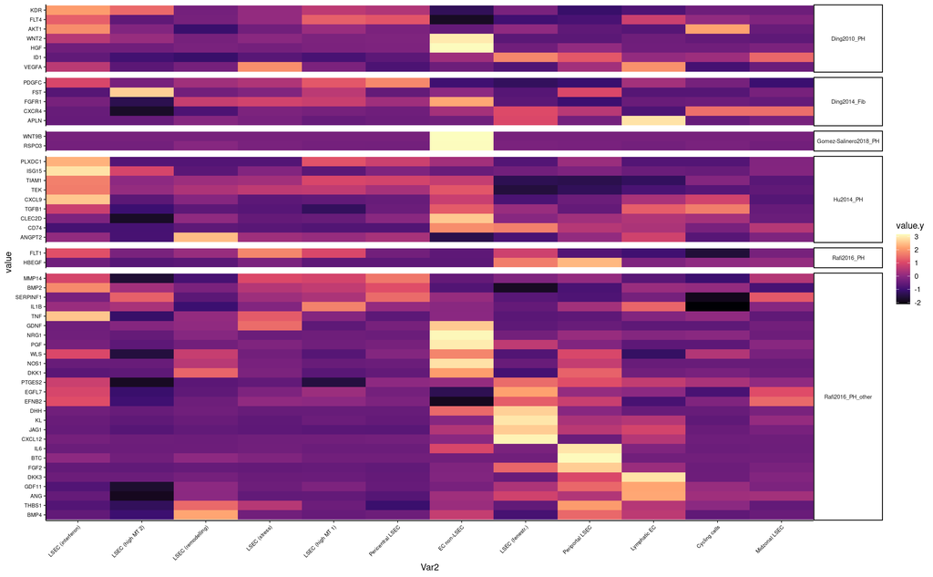

```r
ggplot(avg_endo_meta, aes(x = Var2, y = value, fill = value.y))+
  facet_grid(L1~., scales = "free", space = "free")+
  geom_tile()+
  scale_x_discrete(expand = c(0,0))+
  scale_fill_viridis_c(option = "A")+
  theme_classic()+
  theme(strip.text.y = element_text(angle = 0, size = 7),
        axis.text = element_text(size = 6.5, colour = "black"),
        axis.text.x = element_text(angle = 45, hjust = 1, vjust = 1))
```

Prepare data

```r
only_end_cells$endo_simp_cond = paste0(only_end_cells$endo_simp, "..", only_end_cells$Condition)
avg_endo_cond = AverageExpression(only_end_cells, assays = "SCT", group.by = "endo_simp_cond")$SCT
avg_endo_cond = avg_endo_cond[,grepl("LSEC ", colnames(avg_endo_cond)) |
                                grepl(" LSEC", colnames(avg_endo_cond))]
avg_endo_cond = avg_endo_cond[rowSums(avg_endo_cond)>0,]
```

Plot all genes per condition

```r
avg_endoc_meta = merge(genes_endo, reshape2::melt(t(scale(t(avg_endo_cond)))), by = 1)

avg_sum_mat = avg_endo_cond[,grepl("heal", colnames(avg_endo_cond))]+avg_endo_cond[,grepl("regen", colnames(avg_endo_cond))]+avg_endo_cond[,grepl("embo", colnames(avg_endo_cond))]
colnames(avg_sum_mat) = unlist(lapply(strsplit(colnames(avg_sum_mat), "..", fixed = T), function(x) x[1]))

# clustering
#hc_rows = hclust(dist(t(scale(t(avg_endo_cond[unique(avg_endoc_meta$value),])))), method = "ward.D2")
#hc_cols = hclust(dist(scale(t(avg_endo_cond[unique(avg_endoc_meta$value),]))), method = "ward.D2")
hc_rows = hclust(dist(t(scale(t(avg_sum_mat[unique(avg_endoc_meta$value),])))), method = "ward.D2")
hc_cols = hclust(dist(scale(t(avg_sum_mat[unique(avg_endoc_meta$value),]))), method = "ward.D2")

avg_endoc_meta$value = factor(avg_endoc_meta$value, levels = hc_rows$labels[hc_rows$order])
#avg_endoc_meta$Var2 = factor(avg_endoc_meta$Var2, levels = hc_cols$labels[hc_cols$order])

# split cell type and condition
avg_endoc_meta$endo_simp = unlist(lapply(strsplit(as.character(avg_endoc_meta$Var2), "..", fixed = T),
                                        function(x) x[1]))
#avg_endoc_meta$endo_simp = factor(avg_endoc_meta$endo_simp, levels = unique(avg_endoc_meta$endo_simp))
avg_endoc_meta$endo_simp = factor(avg_endoc_meta$endo_simp,
                                  levels = rev(hc_cols$labels[hc_cols$order]))
avg_endoc_meta$cond = unlist(lapply(strsplit(as.character(avg_endoc_meta$Var2), "..", fixed = T),
                                   function(x) x[2]))
avg_endoc_meta$cond = factor(avg_endoc_meta$cond, levels = c("healthy", "regenerating", "embolised"))
```

Plot all genes per condition, no paper

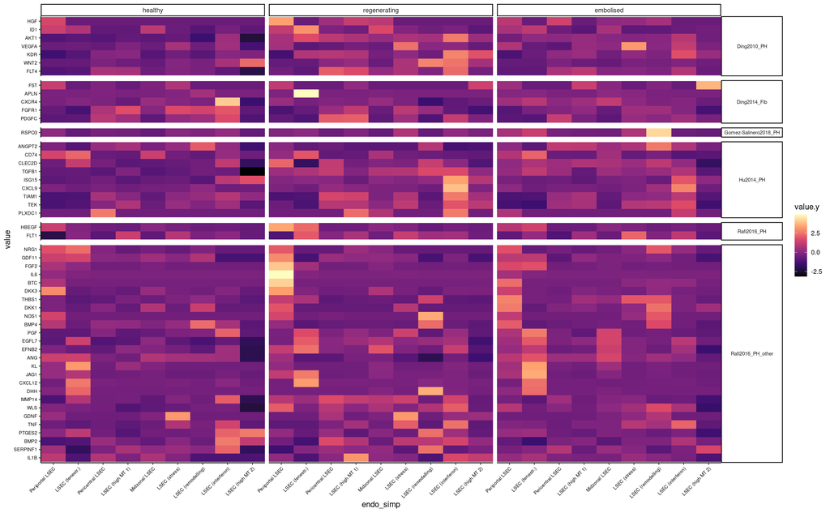

```r
ggplot(avg_endoc_meta, aes(x = endo_simp, y = value, fill = value.y))+
  facet_grid(L1~cond, scales = "free", space = "free")+
  geom_tile()+
  scale_x_discrete(expand = c(0,0))+
  scale_fill_viridis_c(option = "A")+
  theme_classic()+
  theme(strip.text.y = element_text(angle = 0, size = 7),
        axis.text = element_text(size = 6.5, colour = "black"),
        axis.text.x = element_text(angle = 45, hjust = 1, vjust = 1))
```

Get interactions

```r
plt_mean = ggplot(avg_endoc_meta, aes(x = endo_simp, y = value, fill = value.y))+
  facet_grid(.~cond, scales = "free", space = "free")+
  geom_tile()+
  scale_x_discrete(expand = c(0,0))+
  scale_fill_viridis_c(option = "A")+
  labs(x = "cell types", y = "genes", fill = "scaled\navg. exp.")+
  theme_classic()+
  theme(strip.text = element_text(angle = 0, size = 6.5),
        axis.text = element_text(size = 6, colour = "black"),
        axis.text.x = element_text(angle = 45, hjust = 1, vjust = 1),
        axis.title = element_text(size = 6.5),
        legend.title = element_text(size = 6.5),
        legend.text = element_text(size = 6))

pdf("figure_panels_rev2/fig_comm/endo_expression_angiocrine.pdf", height = 4.8, width = 6)
print(plt_mean)
dev.off()
```

Strict interactions

```r
inter_df = readRDS(file = "results/cell_comm/v3/cond_diff_interact_DE.RDS")[1:3]
inter_df = reshape2::melt(lapply(inter_df, function(x) x[,c(1:8)]),
                          id.vars = colnames(inter_df$healthy[,c(1:8)]))
inter_df$ct_pair = paste0(inter_df$ct1, "..", inter_df$ct2)
inter_df$lr_pair = paste0(inter_df$lr1, "..", inter_df$lr2)

inter_df_endo = inter_df[inter_df$ct1 %in% unique(only_end_cells$endo_simp) |
                           inter_df$ct2 %in% unique(only_end_cells$endo_simp),]
```

Plot all strict

```r
inter_df_str = unique(inter_df_endo[inter_df_endo$gn1 %in% genes_endo$value &
                          inter_df_endo$gn2 %in% genes_endo$value,
                          c("ct_pair", "lr_pair", "value", "L1")])
```

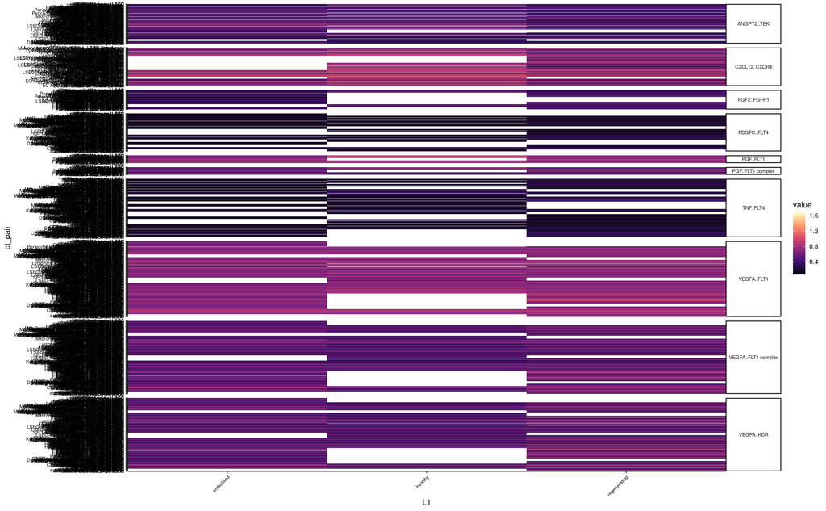

```r
ggplot(inter_df_str, aes(x = L1, y = ct_pair, fill = value))+
  facet_grid(lr_pair~., scales = "free", space = "free")+
  geom_tile()+
  scale_x_discrete(expand = c(0,0))+
  scale_fill_viridis_c(option = "A")+
  theme_classic()+
  theme(strip.text.y = element_text(angle = 0, size = 7),
        axis.text = element_text(size = 6.5, colour = "black"),
        axis.text.x = element_text(angle = 45, hjust = 1, vjust = 1))
```

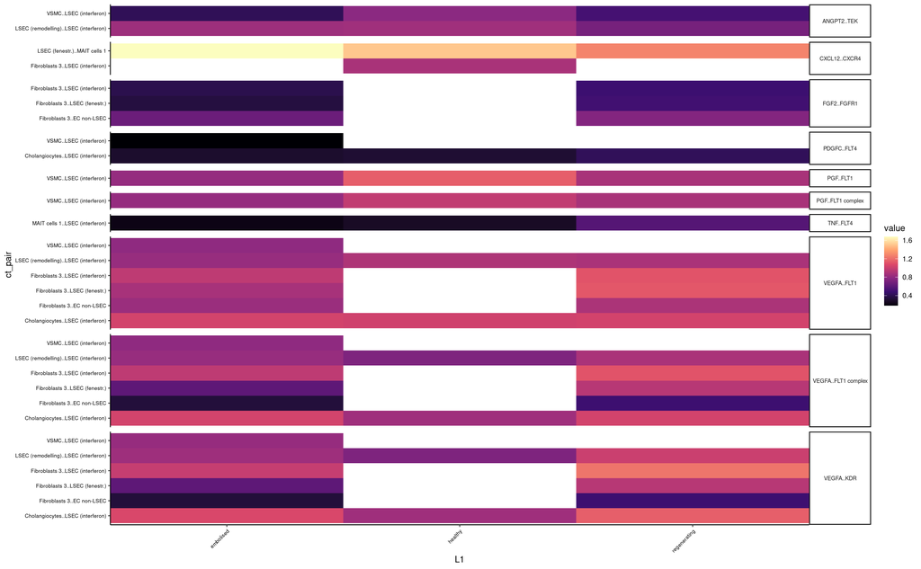

```r
inter_df_sub = inter_df_str %>% group_by(lr_pair) %>% top_n(value, n=1)
inter_df_sub = inter_df_str[inter_df_str$ct_pair %in% inter_df_sub$ct_pair &
                              inter_df_str$lr_pair %in% inter_df_sub$lr_pair,]
ggplot(inter_df_sub, aes(x = L1, y = ct_pair, fill = value))+
  facet_grid(lr_pair~., scales = "free", space = "free")+
  geom_tile()+
  scale_x_discrete(expand = c(0,0))+
  scale_fill_viridis_c(option = "A", na.value = 0)+
  theme_classic()+
  theme(strip.text.y = element_text(angle = 0, size = 7),
        axis.text = element_text(size = 6.5, colour = "black"),
        axis.text.x = element_text(angle = 45, hjust = 1, vjust = 1))
```

Plot normalised counts

```r
inter_df_endo2 = inter_df[grepl("LSEC ", inter_df$ct1) | grepl(" LSEC", inter_df$ct1),]
inter_df_sub = unique(inter_df_endo2[inter_df_endo2$gn1 %in% genes_endo$value |
                                       inter_df_endo2$gn2 %in% genes_endo$value,
                                     c("ct1", "ct2", "ct_pair", "lr_pair", "value")])
inter_df_endo_u = unique(inter_df_endo2[,c("ct1", "ct2", "ct_pair", "lr_pair", "value")])

n_angio = table(inter_df_sub$ct1, inter_df_sub$ct2)
f_angio_all = n_angio
for(n in colnames(f_angio_all)){
  f_angio_all[,n] = f_angio_all[,n]/log10(table(inter_df_endo_u$ct2)[n])
}
```

Per condition

```r
plot_df = reshape2::melt(f_angio_all[order(rowSums(f_angio_all), decreasing = F),
                                     order(colSums(f_angio_all), decreasing = T)])
plot_df$isLSEC = c("other", "LSEC")[(grepl("LSEC ", plot_df$Var2) | grepl(" LSEC", plot_df$Var2))+1]

cnt_int = ggplot(plot_df, aes(x = Var2, y = Var1, fill = value))+
  facet_grid(~isLSEC, scale = "free_x", space = "free_x")+
  geom_tile()+
  scale_fill_viridis_c(option = "B")+
  scale_x_discrete(expand = c(0,0))+
  scale_y_discrete(expand = c(0,0))+
  labs(fill = "# interactions\n(norm.)", x = "Receiving cell type",
       y = "Sending cell type")+
  theme_classic()+
  theme(axis.text = element_text(colour = "black", size = 6),
        axis.text.x = element_text(angle = 60, hjust = 1, vjust = 1),
        legend.text = element_text(size = 6),
        legend.title = element_text(size = 6.5),
        axis.title = element_text(size = 6.5),
        strip.text = element_text(size = 6.5))
```

Plot normalised counts (norm per total)

```r
inter_df_endo2 = inter_df[grepl("LSEC ", inter_df$ct1) | grepl(" LSEC", inter_df$ct1),]
inter_df_sub = unique(inter_df_endo2[inter_df_endo2$gn1 %in% genes_endo$value,
                                     c("ct1", "ct2", "ct_pair", "lr_pair", "value", "L1")])
inter_df_endo_u = unique(inter_df_endo2[,c("ct1", "ct2", "ct_pair", "lr_pair", "value", "L1")])

f_list = list()
for(cond in c("healthy", "regenerating", "embolised")){
  inter_df_sub2 = inter_df_sub[inter_df_sub$L1==cond,]
  n_angio = table(inter_df_sub2$ct1, inter_df_sub2$ct2)
  f_angio = n_angio
  for(n in colnames(f_angio)){
    f_angio[,n] = f_angio[,n]/log10(table(inter_df_endo_u$ct2)[n])
  }
  f_list[[cond]] = f_angio[order(rowSums(f_angio_all), decreasing = F),
                           order(colSums(f_angio_all), decreasing = T)]
}
```

Per condition, unique healthy vs PVE

```r
plot_df_cond = reshape2::melt(f_list)
plot_df_cond$isLSEC = c("other", "LSEC")[(grepl("LSEC ", plot_df_cond$Var2) |
                                            grepl(" LSEC", plot_df_cond$Var2))+1]
plot_df_cond$L1[plot_df_cond$L1=="embolised"] = "embolized"
plot_df_cond$L1 = factor(plot_df_cond$L1, levels = c("healthy", "regenerating", "embolized"))

cnt_int_cond = ggplot(plot_df_cond, aes(x = Var2, y = Var1, fill = value))+
  facet_grid(L1~isLSEC, scale = "free_x", space = "free_x")+
  geom_tile()+
  scale_fill_viridis_c(option = "B")+
  scale_x_discrete(expand = c(0,0))+
  scale_y_discrete(expand = c(0,0))+
  labs(fill = "# interactions\n(norm.)", x = "Receiving cell type",
       y = "Sending cell type")+
  theme_classic()+
  theme(axis.text = element_text(colour = "black", size = 6),
        axis.text.x = element_text(angle = 60, hjust = 1, vjust = 1),
        legend.text = element_text(size = 6),
        legend.title = element_text(size = 6.5),
        axis.title = element_text(size = 6.5),
        strip.text = element_text(size = 6.5))

pdf("figure_panels_rev2/fig_comm/endo_interactions_angiocrine_allInter.pdf", height = 4.45,
    width = 6.8)
print(cnt_int_cond)
dev.off()
```

Plot normalised counts (norm per total)

```r
inter_df_endo2 = inter_df[grepl("LSEC ", inter_df$ct1) | grepl(" LSEC", inter_df$ct1),]
inter_df_endo2$ct1 = factor(inter_df_endo2$ct1)
inter_df_endo2$ct2 = factor(inter_df_endo2$ct2)
inter_df_sub = unique(inter_df_endo2[inter_df_endo2$gn1 %in% genes_endo$value,
                                     c("ct1", "ct2", "ct_pair", "lr_pair", "value", "L1")])
inter_df_endo_u = unique(inter_df_endo2[,c("ct1", "ct2", "ct_pair", "lr_pair", "value", "L1")])

int_h = setdiff(inter_df_endo_u[inter_df_endo_u$L1=="healthy", "lr_pair"],
                inter_df_endo_u[inter_df_endo_u$L1!="healthy", "lr_pair"])
int_r = setdiff(inter_df_endo_u[inter_df_endo_u$L1!="healthy", "lr_pair"],
                inter_df_endo_u[inter_df_endo_u$L1=="healthy", "lr_pair"])

f_spec_list = list()
for(cond in c("healthy", "regenerating", "embolised")){
  int_use = if(cond=="healthy") int_h else int_r

  inter_df_sub2 = inter_df_sub[inter_df_sub$L1==cond & inter_df_sub$lr_pair %in% int_use,]
  inter_df_endo_u2 = inter_df_endo_u[inter_df_endo_u$L1==cond & inter_df_endo_u$lr_pair %in% int_use,]
  n_angio = table(inter_df_sub2$ct1, inter_df_sub2$ct2)
  f_angio = n_angio
  for(n in colnames(f_angio)){
    f_angio[,n] = f_angio[,n]/log10(table(inter_df_endo_u$ct2)[n])
  }
  f_spec_list[[cond]] = f_angio[order(rowSums(f_angio_all), decreasing = F),
                                order(colSums(f_angio_all), decreasing = T)]
}
```

Per condition, in 2 cond only

```r
plot_df_spec = reshape2::melt(f_spec_list)
plot_df_spec$isLSEC = c("other", "LSEC")[(grepl("LSEC ", plot_df_spec$Var2) |
                                            grepl(" LSEC", plot_df_spec$Var2))+1]
plot_df_spec$L1[plot_df_spec$L1=="embolised"] = "embolized"
plot_df_spec$L1 = factor(plot_df_spec$L1, levels = c("healthy", "regenerating", "embolized"))

cnt_int_spec = ggplot(plot_df_spec, aes(x = Var2, y = Var1, fill = value))+
  facet_grid(L1~isLSEC, scale = "free_x", space = "free_x")+
  geom_tile()+
  scale_fill_viridis_c(option = "B")+
  scale_x_discrete(expand = c(0,0))+
  scale_y_discrete(expand = c(0,0))+
  labs(fill = "# interactions\n(norm.)", x = "Receiving cell type",
       y = "Sending cell type")+
  theme_classic()+
  theme(axis.text = element_text(colour = "black", size = 6),
        axis.text.x = element_text(angle = 60, hjust = 1, vjust = 1),
        legend.text = element_text(size = 6),
        legend.title = element_text(size = 6.5),
        axis.title = element_text(size = 6.5),
        strip.text = element_text(size = 6.5))

pdf("figure_panels_rev2/fig_comm/endo_interactions_angiocrine_healthyVSPVE.pdf", height = 4.45,
    width = 6.8)
print(cnt_int_spec)
dev.off()
```

Plot normalised counts (norm per total)

```r
inter_df_endo2 = inter_df[grepl("LSEC ", inter_df$ct1) | grepl(" LSEC", inter_df$ct1),]
inter_df_endo2$ct1 = factor(inter_df_endo2$ct1)
inter_df_endo2$ct2 = factor(inter_df_endo2$ct2)
inter_df_sub = unique(inter_df_endo2[inter_df_endo2$gn1 %in% genes_endo$value,
                                     c("ct1", "ct2", "ct_pair", "lr_pair", "value", "L1")])
inter_df_endo_u = unique(inter_df_endo2[,c("ct1", "ct2", "ct_pair", "lr_pair", "value", "L1")])

inter_cond_u = unique(inter_df_endo_u[inter_df_endo_u$lr_pair %in% inter_df_sub$lr_pair,
                                      c("L1", "lr_pair")])
int_use = table(inter_cond_u$lr_pair,inter_cond_u$L1)
int_use = rownames(int_use)[rowSums(int_use)<3]

f_spec2_list = list()
for(cond in c("healthy", "regenerating", "embolised")){
  inter_df_sub2 = inter_df_sub[inter_df_sub$L1==cond & inter_df_sub$lr_pair %in% int_use,]
  inter_df_endo_u2 = inter_df_endo_u[inter_df_endo_u$L1==cond & inter_df_endo_u$lr_pair %in% int_use,]
  n_angio = table(inter_df_sub2$ct1, inter_df_sub2$ct2)
  f_angio = n_angio
  for(n in colnames(f_angio)){
    f_angio[,n] = f_angio[,n]/log10(table(inter_df_endo_u$ct2)[n])
  }
  f_spec2_list[[cond]] = f_angio[order(rowSums(f_angio_all), decreasing = F),
                                order(colSums(f_angio_all), decreasing = T)]
}
```

```r
plot_df_spec2 = reshape2::melt(f_spec2_list)
plot_df_spec2$isLSEC = c("other", "LSEC")[(grepl("LSEC ", plot_df_spec2$Var2) |
                                            grepl(" LSEC", plot_df_spec2$Var2))+1]
plot_df_spec2$L1[plot_df_spec2$L1=="embolised"] = "embolized"
plot_df_spec2$L1 = factor(plot_df_spec2$L1, levels = c("healthy", "regenerating", "embolized"))

cnt_int_spec2 = ggplot(plot_df_spec2, aes(x = Var2, y = Var1, fill = value))+
  facet_grid(L1~isLSEC, scale = "free_x", space = "free_x")+
  geom_tile()+
  scale_fill_viridis_c(option = "B")+
  scale_x_discrete(expand = c(0,0))+
  scale_y_discrete(expand = c(0,0))+
  labs(fill = "# interactions\n(norm.)", x = "Receiving cell type",
       y = "Sending cell type")+
  theme_classic()+
  theme(axis.text = element_text(colour = "black", size = 6),
        axis.text.x = element_text(angle = 60, hjust = 1, vjust = 1),
        legend.text = element_text(size = 6),
        legend.title = element_text(size = 6.5),
        axis.title = element_text(size = 6.5),
        strip.text = element_text(size = 6.5))

pdf("figure_panels_rev2/fig_comm/endo_interactions_angiocrine_any2cond.pdf", height = 4.45,
    width = 6.8)
print(cnt_int_spec2)
dev.off()
```